# Using `nullranges::matchranges()` with `BentoBox`

Eric S. Davis

08/05/2021

This lightning talk will attempt to use a toy dataset to generate covariate-matched, null-hypothesis GRanges with `nullranges::matchRanges()` and then visualize the results using the `BentoBox` framework.

## Generating covariate-matched GRanges

For this example lets use a utility function to create a simulated dataset:

```r
set.seed(123)
x <- Bioc2021::makeExampleMatchedDataSet(type = "GRanges")
x
```

```
## GRanges object with 136 ranges and 3 metadata columns:
##         seqnames    ranges strand |  feature1       color    length
##            <Rle> <IRanges>  <Rle> | <logical> <character> <integer>
##     [1]     chr1    92-200      * |      TRUE     #4fbe9b       109
##     [2]     chr1    71-178      * |      TRUE     #d098d7       108
##     [3]     chr1   747-902      * |      TRUE     #e19995       156
##     [4]     chr1   362-502      * |      TRUE     #d098d7       141
##     [5]     chr1   339-406      * |      TRUE     #d098d7        68
##     ...      ...       ...    ... .       ...         ...       ...
##   [132]     chr1   511-606      * |     FALSE     #d098d7        96
##   [133]     chr1   724-847      * |     FALSE     #4fbe9b       124
##   [134]     chr1    72-172      * |     FALSE     #4fbe9b       101
##   [135]     chr1   341-480      * |     FALSE     #4fbe9b       140
##   [136]     chr1   674-734      * |     FALSE     #d098d7        61
##   -------
##   seqinfo: 1 sequence from an unspecified genome; no seqlengths
```

This creates a GRanges object with random ranges and 3 metadata colums (`feature1`, `color`, and `length`) that describe “features” of each range.

Let’s demonstrate generating a set of matched ranges by finding ranges that are `FALSE` for `feature1` but have the same distributions of `color` and `length`.

Our `focal` set of interest is where feature1 is `TRUE`, and `pool` is all other ranges (where feature1 is `FALSE`):

```r
focal <- x[x$feature1]
pool <- x[!x$feature1]
```

We can use `nullranges::matchRanges()` to select a subset from pool that is distributionally matched in color and range length:

```r
library(nullranges)
mgr <- matchRanges(focal = focal,
                   pool = pool,
                   covar = ~color + length,
                   method = 'stratified',
                   replace = FALSE)

mgr
```

```
## MatchedGRanges object with 16 ranges and 3 metadata columns:
##        seqnames    ranges strand |  feature1       color    length
##           <Rle> <IRanges>  <Rle> | <logical> <character> <integer>
##    [1]     chr1    54-164      * |     FALSE     #4fbe9b       111
##    [2]     chr1   624-730      * |     FALSE     #d098d7       107
##    [3]     chr1   357-508      * |     FALSE     #e19995       152
##    [4]     chr1   755-893      * |     FALSE     #d098d7       139
##    [5]     chr1   179-230      * |     FALSE     #d098d7        52
##    ...      ...       ...    ... .       ...         ...       ...
##   [12]     chr1   394-445      * |     FALSE     #6eb3d9        52
##   [13]     chr1   599-668      * |     FALSE     #4fbe9b        70
##   [14]     chr1   700-763      * |     FALSE     #4fbe9b        64
##   [15]     chr1   514-660      * |     FALSE     #d098d7       147
##   [16]     chr1   448-478      * |     FALSE     #adaf64        31
##   -------
##   seqinfo: 1 sequence from an unspecified genome; no seqlengths
```

`overview` can show how successful our matching was:

```r
overview(mgr)
```

```
## MatchedGRanges object:
##        set   N color.#4fbe9b color.#6eb3d9 color.#adaf64 color.#d098d7
##      focal  16             4             2             3             6
##    matched  16             5             2             2             6
##       pool 120            30            24            22            22
##  unmatched 104            25            22            20            16
##  color.#e19995 length.mean length.sd ps.mean ps.sd
##              1         110        56    0.15 0.059
##              1         100        58    0.15 0.061
##             22         110        49    0.11 0.057
##             21         110        48    0.11 0.055
## --------
## focal - matched:
##  color.#4fbe9b color.#6eb3d9 color.#adaf64 color.#d098d7 color.#e19995
##             -1             0             1             0             0
##  length.mean length.sd  ps.mean   ps.sd
##          3.4      -2.1 -0.00098 -0.0017
```

## Visualizing with BentoBox

Defining the region to plot:

```r
library(BentoBox)
region <- bbParams(chrom = "chr1", chromstart = 1, chromend = 1000)
```

We can visualize these ranges by creating a `BentoBox` page:

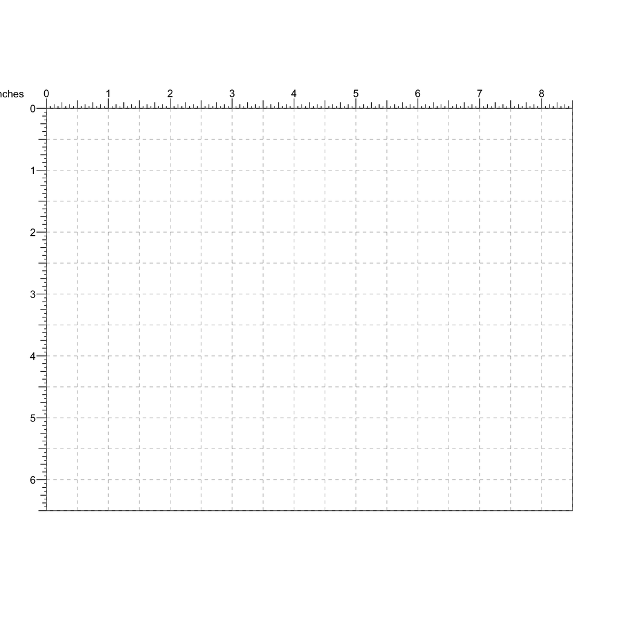

```r
bbPageCreate(width = 8.5, height = 6.5, default.units = 'inches')
```

Visualize the `pool` GRanges:

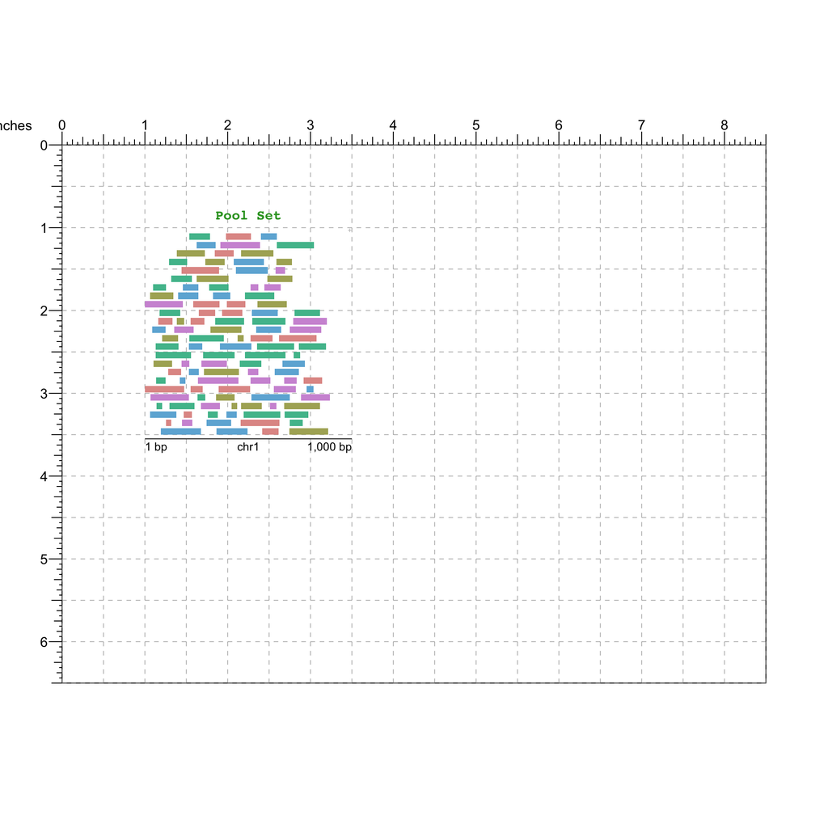

```r
poolSet <- bbPlotRanges(data = pool,
                        params = region,
                        x = 1,
                        y = 1,
                        width = 2.5,
                        height = 2.5,
                        fill = pool$color)

bbAnnoGenomeLabel(plot = poolSet,
                  x = 1,
                  y = 3.55)

bbPlotText(label = "Pool Set",
           x = 2.25,
           y = 0.9,
           just = c("center", "bottom"),
           fontcolor = "#33A02C",
           fontface = "bold",
           fontfamily = 'mono')
```

Visualize the `focal` GRanges of interest:

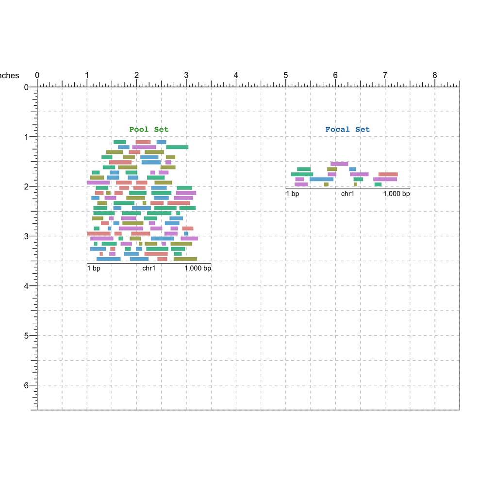

```r
focalSet <- bbPlotRanges(data = focal,
                         params = region,
                         x = 5,
                         y = 1,
                         width = 2.5,
                         height = 1,
                         fill = focal$color)

bbAnnoGenomeLabel(plot = focalSet,
                  x = 5,
                  y = 2.05)

bbPlotText(label = "Focal Set",
           x = 6.25,
           y = 0.9,
           just = c("center", "bottom"),
           fontcolor = "#1F78B4",
           fontface = "bold",
           fontfamily = 'mono')
```

And finally the `matched` GRanges:

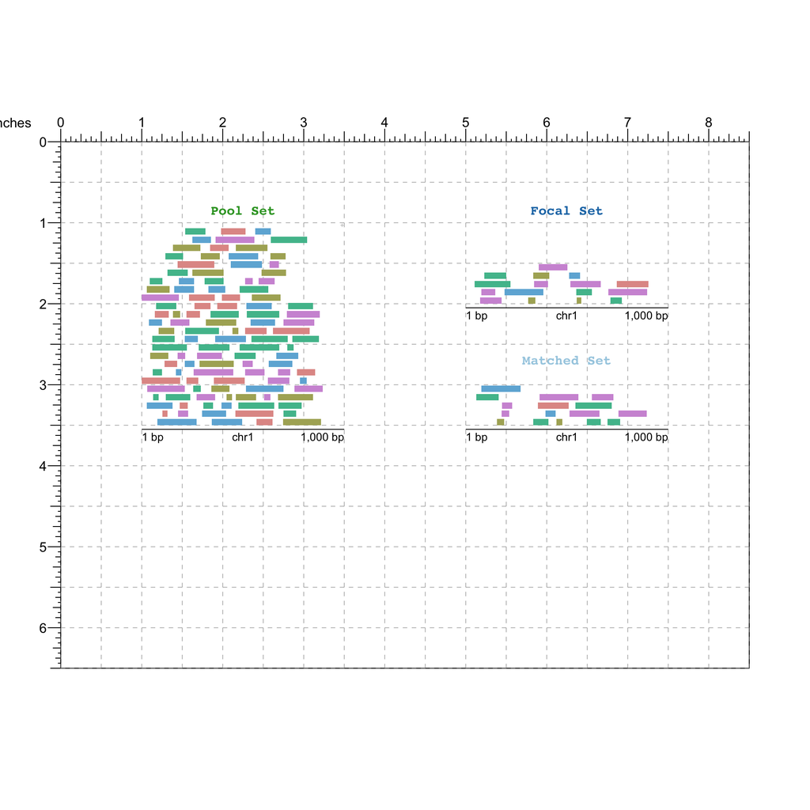

```r
## Matched set
matchedSet <- bbPlotRanges(data = mgr,
                           params = region,
                           x = 5,
                           y = 2.5,
                           width = 2.5,
                           height = 1,
                           fill = mgr$color)

bbAnnoGenomeLabel(plot = matchedSet,
                  x = 5,
                  y = 3.55)

bbPlotText(label = "Matched Set",
           x = 6.25,
           y = 2.75,
           just = c("center", "bottom"),
           fontcolor = "#A6CEE3",
           fontface = "bold",
           fontfamily = 'mono')
```

Below our GRanges, we can use `BentoBox` to place ggplots created from the `nullranges` `plotPropensity()` and `plotCovariate()` functions.

First lets plot propensity scores:

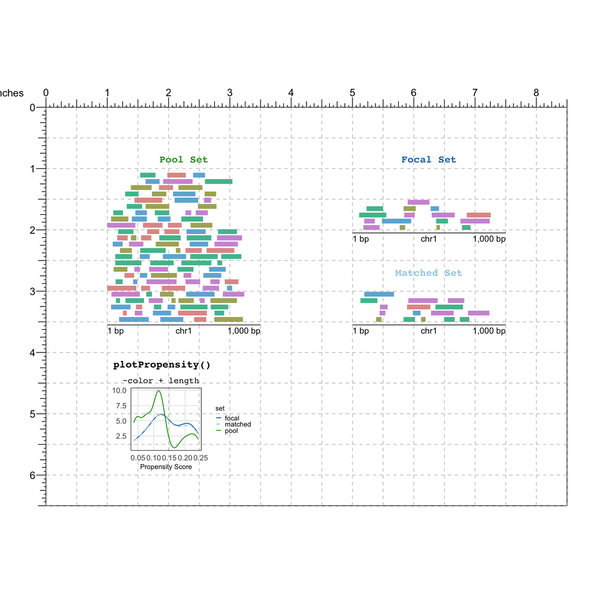

```r
library(ggplot2)
smallText <- theme(legend.title = element_text(size=8),
                   legend.text=element_text(size=8),
                   title = element_text(size=8),
                   axis.title.x = element_text(size=8),
                   axis.title.y = element_text(size=8))

## Plot propensity scores ggplot in BentoBox
propensityPlot <-
  plotPropensity(mgr, sets=c('f','m','p')) +
  smallText +
  theme(legend.key.size = unit(0.5, 'lines'),
        title = element_blank())

bbPlotGG(plot = propensityPlot,
          x = 1, y = 4.5, width = 2.5, height = 1.5,
          just = c("left", "top"))

## Text labels
bbPlotText(label = "plotPropensity()",
            x = 1.10, y = 4.24,
            just = c("left", "bottom"),
            fontface = "bold",
            fontfamily = 'mono')
bbPlotText(label = "~color + length",
            x = 1.25, y = 4.5,
            just = c("left", "bottom"),
            fontsize = 10,
            fontfamily = "mono")
```

plotting `color` and `length` covariates:

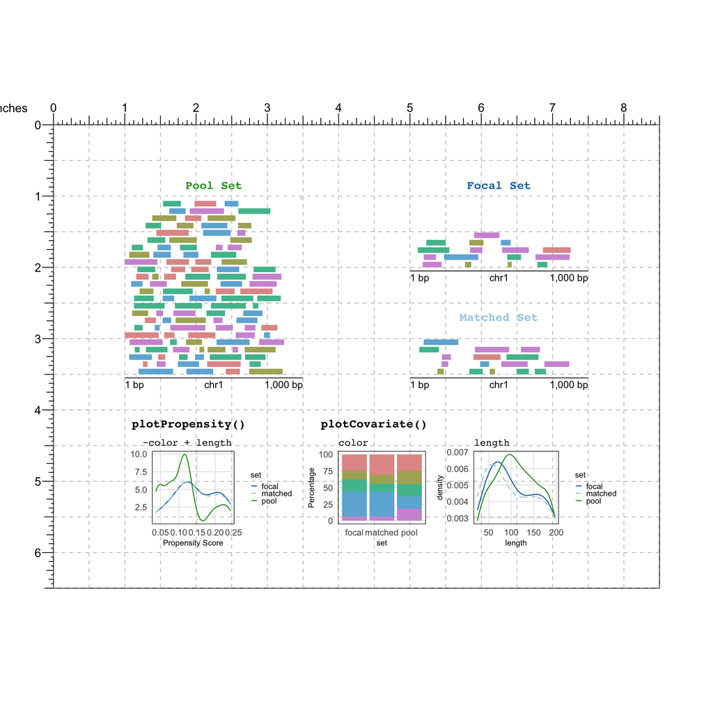

```r
## Plot "color" covariate
covColor <-
  plotCovariate(x=mgr, covar=covariates(mgr)[1], sets=c('f','m','p')) +
  smallText +
  theme(legend.text = element_blank(),
        legend.position = 'none')

bbPlotGG(plot = covColor,
          x = 3.50, y = 4.5, width = 1.8, height = 1.5,
          just = c("left", "top"))


## Plot "length" covariate
covLength <-
  plotCovariate(x=mgr, covar=covariates(mgr)[2], sets=c('f','m','p'))+
  smallText +
  theme(legend.key.size = unit(0.5, 'lines'))

bbPlotGG(plot = covLength,
          x = 5.30, y = 4.5, width = 2.75, height = 1.5,
          just = c("left", "top"))


## Text labels
bbPlotText(label = "plotCovariate()",
           x = 3.75,
           y = 4.24,
           just = c("left", "bottom"),
           fontface = "bold",
           fontfamily = "mono")
bbPlotText(label = covariates(mgr),
           x = c(4, 5.9),
           y = 4.5,
           just = c("left", "bottom"),
           fontsize = 10,
           fontfamily = "mono")
```

When the plot is finished you can remove the page guides:

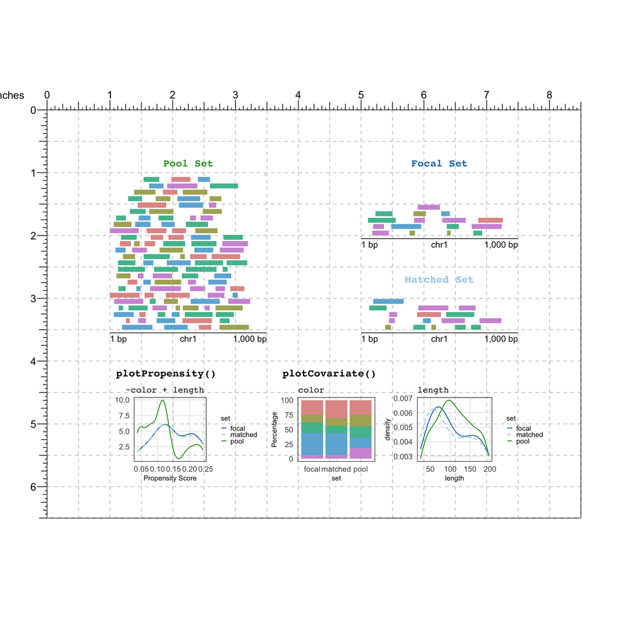

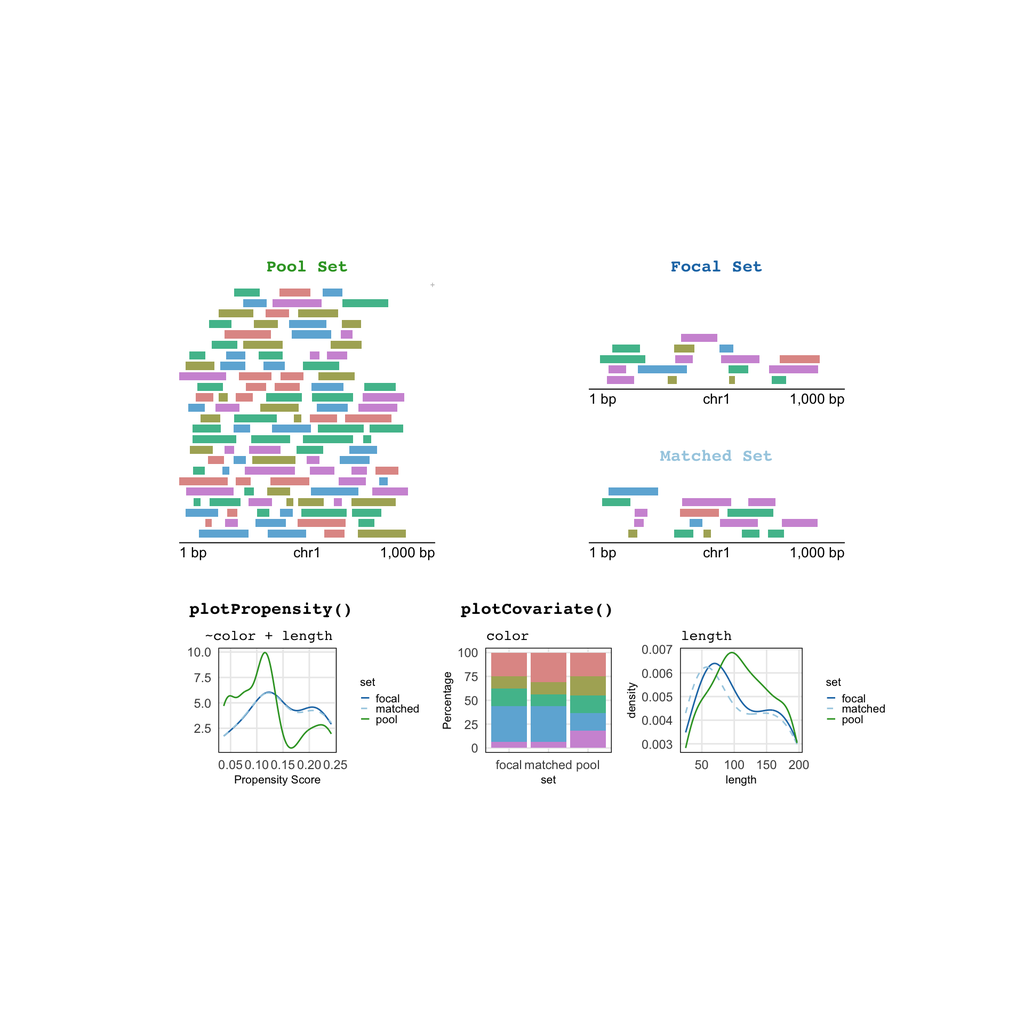

```r
bbPageGuideHide()
```

And now your plot is publication-ready!